# Penalized regressions

## Exercise 2 (variable selection)

We consider the model
$$Y=\beta_0+\beta_1X_1+\dots+\beta_pX_p+\varepsilon$$
where $X_1,\dots,X_p$ are independent variables with distribution $\mathcal N(0,1)$ and $\varepsilon$ has distribution $\mathcal N(0,0.5^2)$ ($X=(X_1,\dots,X_p)$ and $\varepsilon$ are independent).

We assume that $p=105$ and that

- $\beta_0=0$, $\beta_1=\dots=\beta_5=1$
- $\beta_6=\dots=\beta_{105}=0$. So here, only variables $X_1,\dots,X_5$ are relevant to explain $Y$.
1. Generate $n=1000$ observations $(x_1,y_1),\dots,(x_n,y_n)$ according to this model. Put these observations in a **data.frame df** with dimension $1000\times 106$.

```r
n <- 1000
p <- 105
set.seed(1234)
X.mat <- matrix(rnorm(n*p),ncol=p)
eps <- rnorm(n,mean = 0,sd=0.5)
df <- data.frame(X.mat,eps)
df <- df %>% mutate(Y=X1+X2+X3+X4+X5+eps) %>% select(-eps)
```

2. Fit a linear model (**lm** function) with *df* and print the estimator of $\beta_0,\dots,\beta_{105}$.

```r
mod.full <- lm(Y~.,data=df)
summary(mod.full)
```

```
##
## Call:
## lm(formula = Y ~ ., data = df)
##
## Residuals:
##      Min       1Q   Median       3Q      Max
## -1.67736 -0.33472  0.00032  0.30319  1.45542
##
## Coefficients:
##               Estimate Std. Error t value Pr(>|t|)
## (Intercept) -0.0130727  0.0166020  -0.787  0.43124
## X1           0.9846185  0.0165621  59.450  < 2e-16 ***
## X2           0.9962524  0.0166838  59.714  < 2e-16 ***
## X3           1.0185854  0.0162804  62.565  < 2e-16 ***
## X4           1.0069154  0.0164305  61.283  < 2e-16 ***
## X5           1.0075293  0.0171871  58.621  < 2e-16 ***
## X6           0.0162413  0.0167867   0.968  0.33355
## X7          -0.0380549  0.0165760  -2.296  0.02192 *
## X8          -0.0138780  0.0163996  -0.846  0.39765
## X9           0.0078099  0.0168906   0.462  0.64392
## X10         -0.0169844  0.0172212  -0.986  0.32428
## X11         -0.0219250  0.0165394  -1.326  0.18530
## X12          0.0035766  0.0164080   0.218  0.82750
## X13         -0.0173715  0.0165630  -1.049  0.29455
## X14          0.0015961  0.0161666   0.099  0.92138
## X15          0.0030420  0.0165937   0.183  0.85459
## X16          0.0123968  0.0167407   0.741  0.45918
## X17         -0.0140972  0.0160033  -0.881  0.37861
## X18          0.0047780  0.0157696   0.303  0.76197
## X19          0.0089718  0.0160524   0.559  0.57636
## X20          0.0120790  0.0166445   0.726  0.46821
## X21         -0.0052803  0.0168198  -0.314  0.75364
## X22          0.0055084  0.0169444   0.325  0.74519
## X23         -0.0119207  0.0165276  -0.721  0.47094
## X24         -0.0279466  0.0168081  -1.663  0.09673 .
## X25          0.0067445  0.0161983   0.416  0.67724
## X26          0.0115625  0.0164784   0.702  0.48306
## X27         -0.0031926  0.0162123  -0.197  0.84393
## X28         -0.0158039  0.0167512  -0.943  0.34571
## X29         -0.0393262  0.0158546  -2.480  0.01331 *
```

[output cut: 67 more lines]

```
## X97          0.0199452  0.0160869   1.240  0.21536
## X98          0.0308105  0.0167190   1.843  0.06568 .
## X99         -0.0049707  0.0167238  -0.297  0.76636
## X100         0.0077319  0.0161819   0.478  0.63290
## X101         0.0116617  0.0166005   0.702  0.48255
## X102         0.0002618  0.0171176   0.015  0.98780
## X103         0.0199205  0.0167189   1.191  0.23378
## X104         0.0143133  0.0165195   0.866  0.38647
## X105        -0.0166893  0.0169788  -0.983  0.32590
## ---
## Signif. codes:  0 '***' 0.001 '**' 0.01 '*' 0.05 '.' 0.1 ' ' 1
##
## Residual standard error: 0.4932 on 894 degrees of freedom
## Multiple R-squared:  0.9592, Adjusted R-squared:  0.9544
## F-statistic: 199.9 on 105 and 894 DF,  p-value: < 2.2e-16
```

3. We propose to make a variable selection procedure with a backward selection approach using **BIC** criterion. You can use *nvmax=30* in **regsubsets**.

To obtain the selective variables, we can look at the following graph

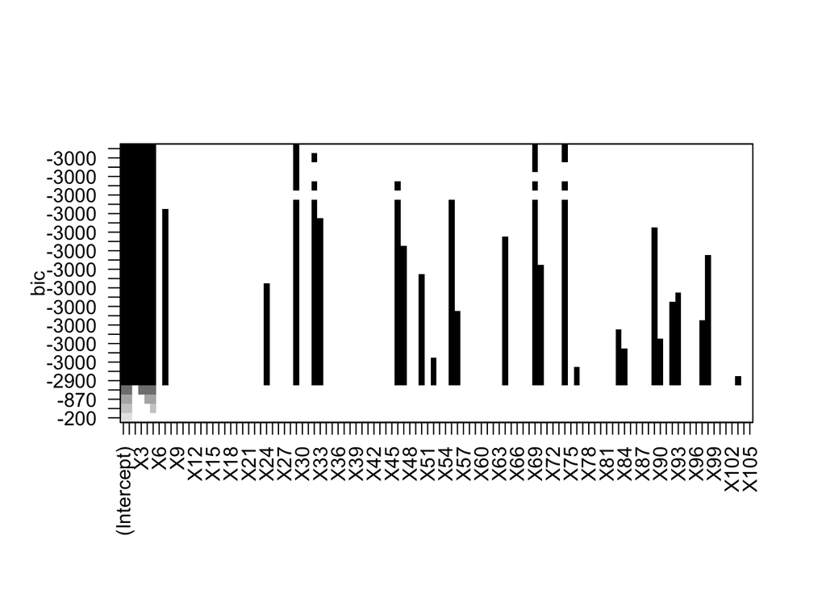

```r
m.back1 <- regsubsets(Y~.,data=df,method="backward",nvmax=30)
plot(m.back1,scale="bic")
```

We can also do that automatically with

```r
a <- summary(m.back1)
number <- order(a$bic)[1]
var.sel <- a$which[number,][-1]
var.sel1 <- names(var.sel)[var.sel] %>% paste(collapse="+")
form.back <- formula(paste("Y~",var.sel1,sep=""))
mod.back <- lm(form.back,data=df)
summary(mod.back)
```

```
##
## Call:
## lm(formula = form.back, data = df)
##
## Residuals:
##      Min       1Q   Median       3Q      Max
## -1.63923 -0.34301  0.00179  0.32041  1.45661
##
## Coefficients:
##              Estimate Std. Error t value Pr(>|t|)
## (Intercept) -0.002413   0.015749  -0.153  0.87828
## X1           0.992339   0.015807  62.777  < 2e-16 ***
## X2           0.991358   0.016097  61.588  < 2e-16 ***
## X3           1.010115   0.015562  64.907  < 2e-16 ***
## X4           1.006043   0.015830  63.552  < 2e-16 ***
## X5           1.008520   0.016242  62.093  < 2e-16 ***
## X29         -0.043358   0.015158  -2.860  0.00432 **
## X69          0.042714   0.015292   2.793  0.00532 **
## X74         -0.043792   0.016118  -2.717  0.00670 **
## ---
## Signif. codes:  0 '***' 0.001 '**' 0.01 '*' 0.05 '.' 0.1 ' ' 1
##
## Residual standard error: 0.4969 on 991 degrees of freedom
## Multiple R-squared:  0.954,  Adjusted R-squared:  0.9537
## F-statistic:  2571 on 8 and 991 DF,  p-value: < 2.2e-16
```

We have selected a model with 8 variables (the 5 relevant variables and 3 noise variables).

```r
m <- 300
p <- 105
set.seed(12345)
X.mat <- matrix(rnorm(m*p),ncol=p)
eps <- rnorm(m,mean = 0,sd=0.5)
df.test <- data.frame(X.mat,eps)
df.test <- df.test %>% mutate(Y=X1+X2+X3+X4+X5+eps) %>% select(-eps)
```

```r
p.full <- predict(mod.full,newdata=df.test)
p.step <- predict(mod.back,newdata=df.test)
pred.df <- data.frame(full=p.full,step=p.step,obs=df.test$Y)
```

```r
pred.df %>% summarise_at(1:2,~mean((obs-.)^2))
```

| full | step |
| --- | --- |
| 0.2997858 | 0.2538291 |

We observe that the selected model has smaller MSE than the full model. We conclude that this model is better for this criterion. We have seen that it is due to the variance of least square estimates: when there are noisy variables in a model, variance of least square estimate increases. These estimates are thus less accurate. To circumvent this problem, we have to select variables (as we do here with the **regsubset** function) or to use regularized methods such as Lasso and Ridge.

# Penalized regression

## Exercise 3 (Lasso and ridge for ozone data)

We consider the same problem as in exercise 1. We propose to fit ridge ans lasso estimates and to compare these models with those of exercise 1.

**glmnet** function requires the $X$ matrix and the $Y$ vector as inputs (we can not use a formula). To compute the $X$ matrix, we use the function **model.matrix**:

```r
train.X <- model.matrix(V4~.,data=train)
test.X <- model.matrix(V4~.,data=test)
```

1. Draw the coefficient paths for ridge and lasso.

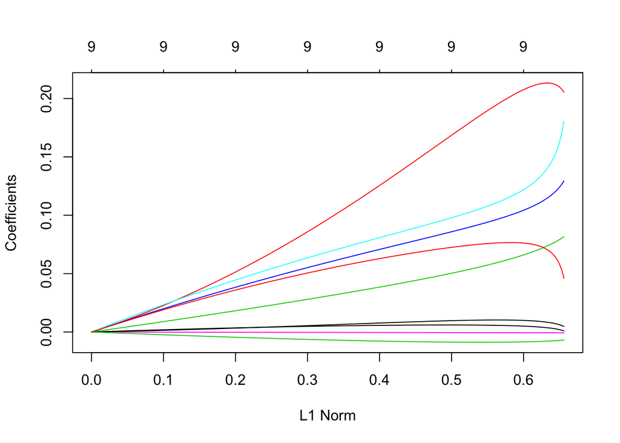

```r
mod.R <- glmnet(train.X,train$V4,alpha=0)
mod.L <- glmnet(train.X,train$V4,alpha=1)

plot(mod.R)
```

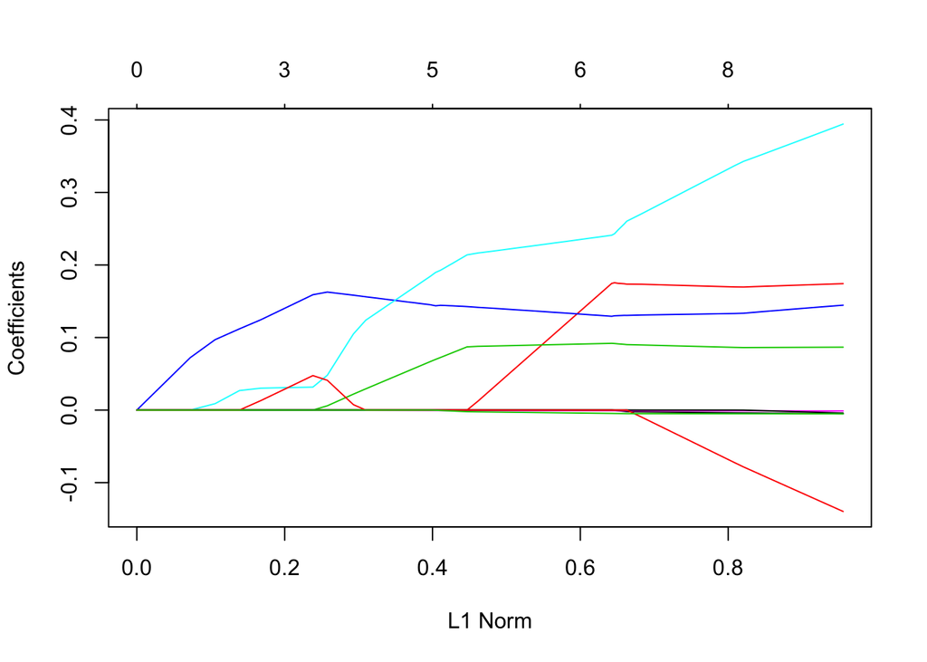

```r
plot(mod.L)
```

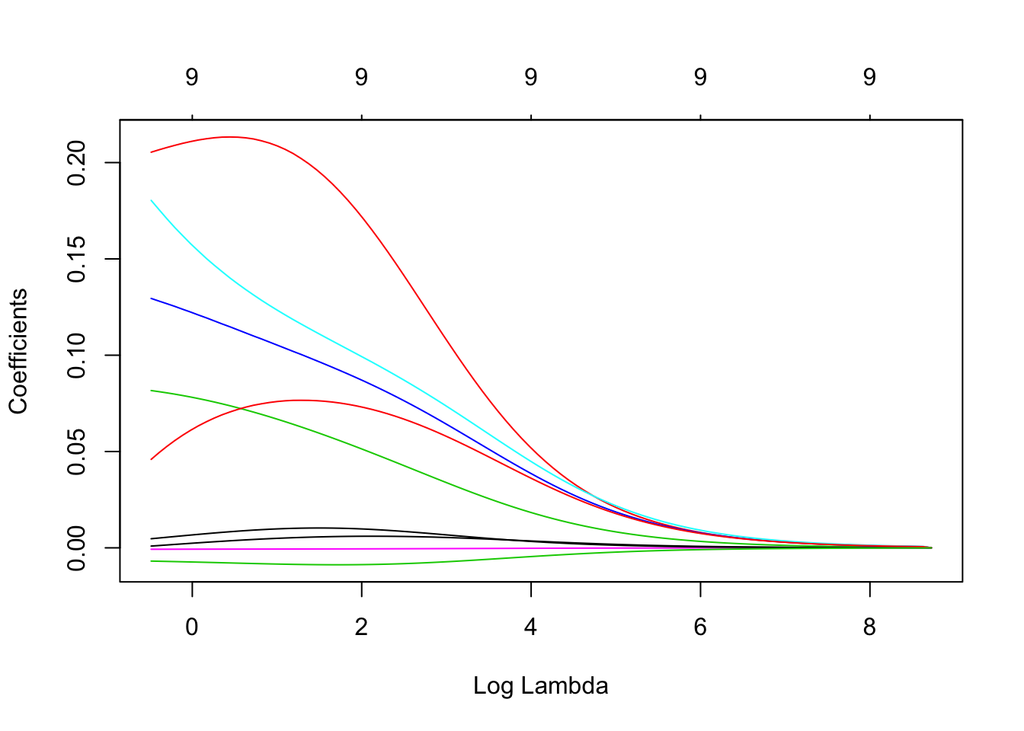

```r
plot(mod.R,xvar="lambda")
```

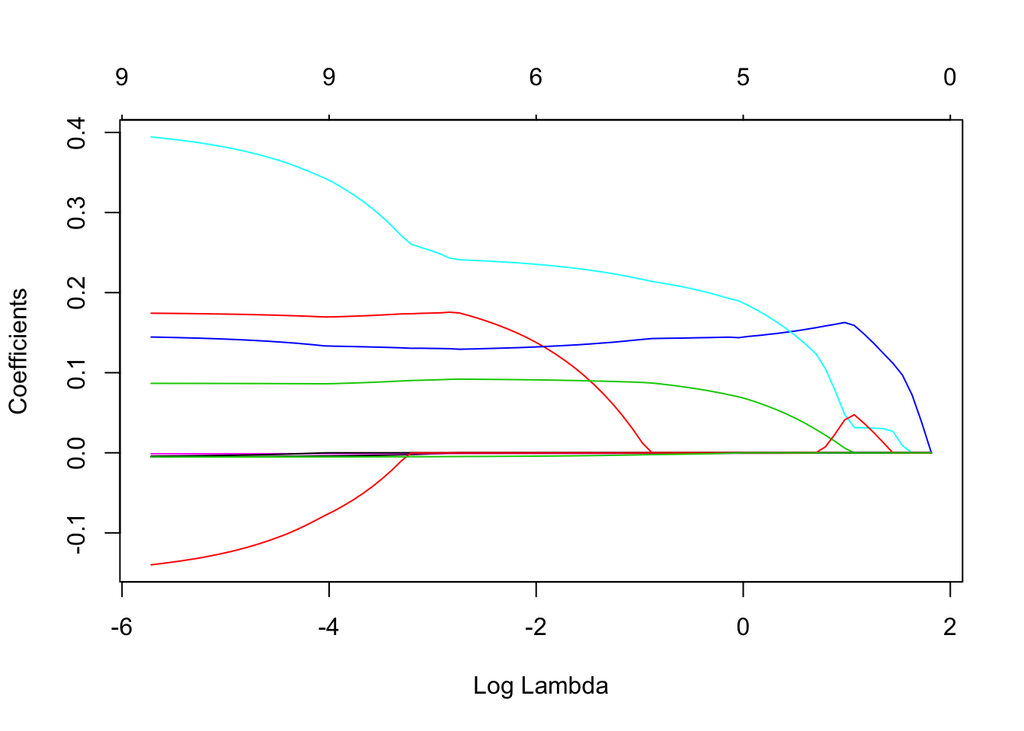

```r
plot(mod.L,xvar="lambda")
```

2. Select the shrinkage parameter for lasso regression with **cv.glmnet**.

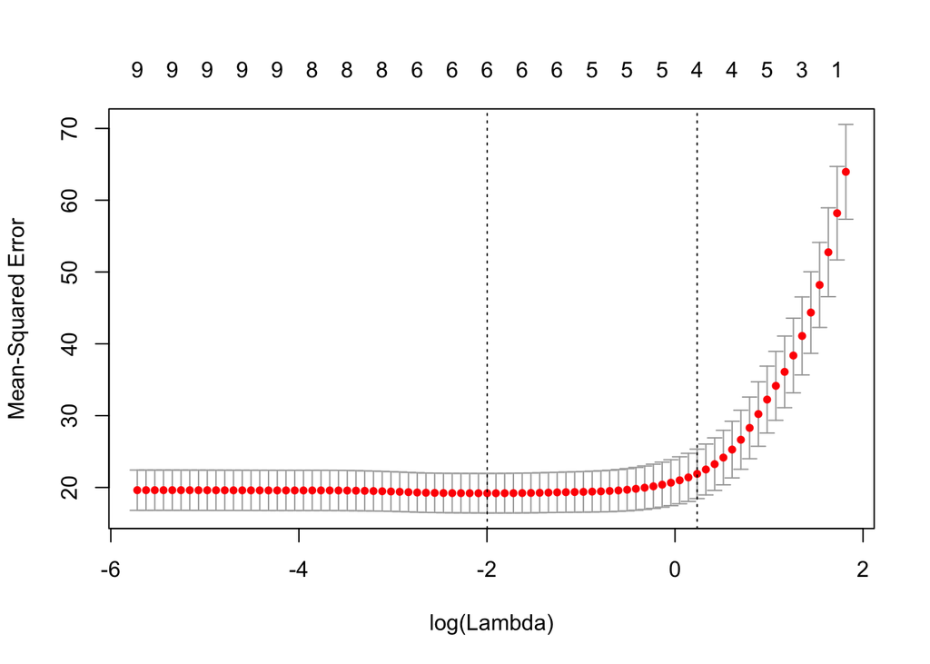

```r
lassoCV <- cv.glmnet(train.X,train$V4,alpha=1)
plot(lassoCV)
```

```r
lassoCV$lambda.min
```

```
## [1] 0.1356943
```

3. Do the same for ridge regression. Explain the problem and solve it.

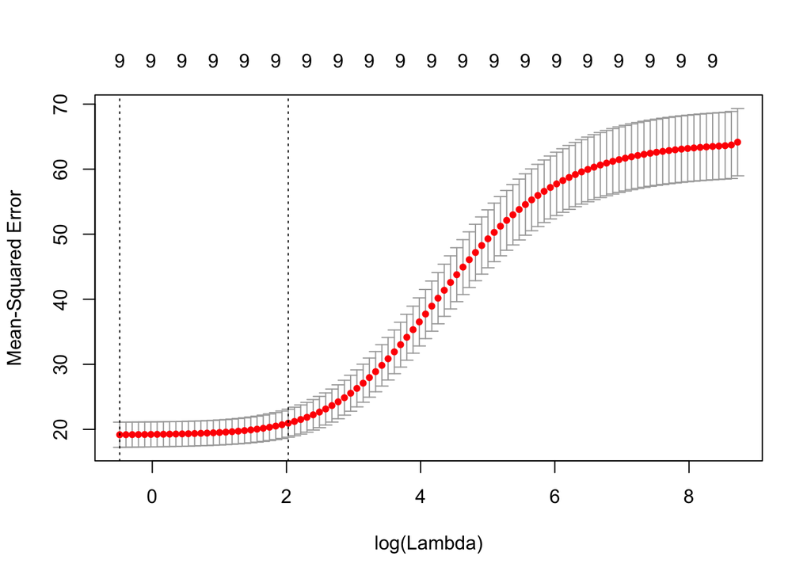

```r
ridgeCV <- cv.glmnet(train.X,train$V4,alpha=0)
plot(ridgeCV)
```

```r
ridgeCV$lambda
```

```
##   [1] 6153.5728042 5606.9063567 5108.8042497 4654.9521610 4241.4190410
##   [6] 3864.6230635 3521.3006022 3208.4779621 2923.4456231 2663.7347716
##  [11] 2427.0959162 2211.4794046 2015.0176696 1836.0090536 1672.9030696
##  [16] 1524.2869718 1388.8735184 1265.4898231 1153.0671951 1050.6318836
##  [21]  957.2966428  872.2530475  794.7644909  724.1598041  659.8274430
##  [26]  601.2101916  547.8003352  499.1352633  454.7934622  414.3908645
##  [31]  377.5775222  344.0345758  313.4714924  285.6235490  260.2495401
##  [36]  237.1296883  216.0637403  196.8692332  179.3799131  163.4442960
##  [41]  148.9243552  135.6943260  123.6396161  112.6558134  102.6477814
##  [46]   93.5288354   85.2199915   77.6492823   70.7511341   64.4657983
##  [51]   58.7388345   53.5206383   48.7660123   44.4337742   40.4864002
##  [56]   36.8897000   33.6125207   30.6264770   27.9057052   25.4266393
##  [61]   23.1678067   21.1096426   19.2343201   17.5255962   15.9686705
##  [66]   14.5500578   13.2574708   12.0797136   11.0065852   10.0287905
##  [71]    9.1378604    8.3260780    7.5864122    6.9124563    6.2983727
##  [76]    5.7388426    5.2290197    4.7644880    4.3412240    3.9555616
##  [81]    3.6041604    3.2839767    2.9922373    2.7264152    2.4842080
##  [86]    2.2635178    2.0624331    1.8792122    1.7122682    1.5601550
##  [91]    1.4215551    1.2952681    1.1802001    1.0753543    0.9798228
##  [96]    0.8927781    0.8134661    0.7412000    0.6753539    0.6153573
```

Here the selected parameter correspond to the minimum value over the grid. We need to change the grid:

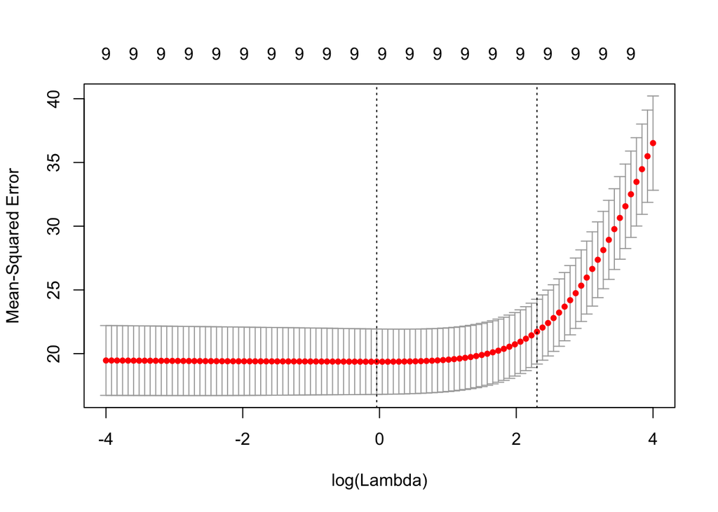

```r
ridgeCV <- cv.glmnet(train.X,train$V4,alpha=0,lambda=exp(seq(-4,4,length=100)))
plot(ridgeCV)
```

It’s better!

```r
ridgeCV$lambda.min
```

```
## [1] 0.9604013
```

4. Estimate the quadratic error for the selected ridge and lasso models. Compare this error with the tree other models:

```r
prev1 <- prev %>% mutate(ridge=as.vector(predict(ridgeCV,newx=test.X,s="lambda.min")),lasso=as.vector(predict(lassoCV,newx=test.X,s="lambda.min")))
prev1 %>% summarize(Err_lin=mean((Y-lin)^2),Err_BIC=mean((Y-BIC)^2),Err_Cp=mean((Y-Cp)^2),Err_ridge=mean((Y-ridge)^2),Err_lasso=mean((Y-lasso)^2))
```

| Err_lin | Err_BIC | Err_Cp | Err_ridge | Err_lasso |
| --- | --- | --- | --- | --- |
| 26.25225 | 28.20783 | 26.11136 | 28.66233 | 27.60155 |

```r
prev1 %>% gather(key="Method",value="Pred",-Y) %>% group_by(Method) %>%
  summarize(Err=mean((Pred-Y)^2)) %>% arrange(Err)
```

| Method | Err |
| --- | --- |
| Cp | 26.11136 |
| lin | 26.25225 |
| lasso | 27.60155 |
| BIC | 28.20783 |
| ridge | 28.66233 |

5. Conclude.

Ridge and lasso are not interesting for this dataset. It is not surprising since we are not in high dimension (only 9 input variables).

## Exercise 4

We consider the spam dataset from the **kernlab** package:

```r
data(spam)
```

We split the data into a training dataset of size 3000 and a test dataset of size 1601.

```r
set.seed(1234)
perm <- sample(nrow(spam))
train <- spam[perm[1:3000],]
test <- spam[perm[3001:4601],]
train.X <- model.matrix(type~.,data=train)
test.X <- model.matrix(type~.,data=test)
```

1. Fit a logistic model on the train dataset with all the variables.

```r
full.logit <- glm(type~.,data=train,family="binomial")
```

2. We propose to make a variable selection procedure with a backward selection approach using **BIC** criterion (this approach will be described in details in other lectures). You just have to use the **step** function with the **direction=“backward”** and **k=log(nrow(train))** options. We call it **mod.back** (it may takes few minutes).

```r
mod.back <- step(full.logit,direction="backward",k=log(nrow(train)),trace=0)
```

3. Fit a logistic lasso model on the training data (select the shrinkage parameter with **cv.glmnet**).

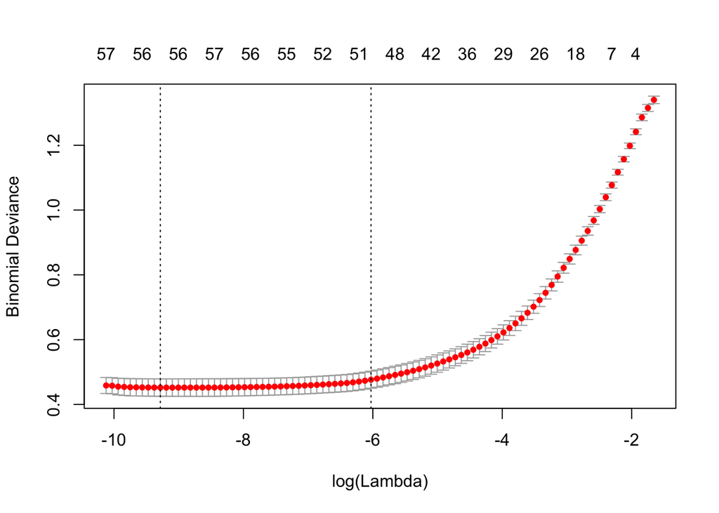

```r
set.seed(1234)
cv.lasso <- cv.glmnet(train.X,train[,58],family="binomial",alpha=1)
plot(cv.lasso)
```

4. Fit a logistic ridge model on the training data (select the shrinkage parameter with **cv.glmnet**).

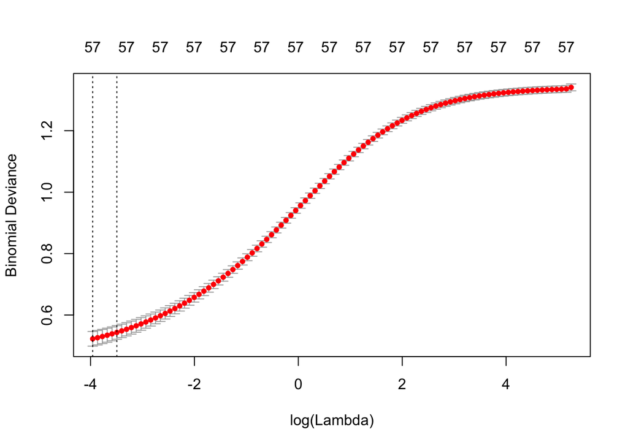

```r
set.seed(1234)
cv.ridge <- cv.glmnet(train.X,train[,58],family="binomial",alpha=0)
plot(cv.ridge)
```

We have to change the grid: default values are too large.

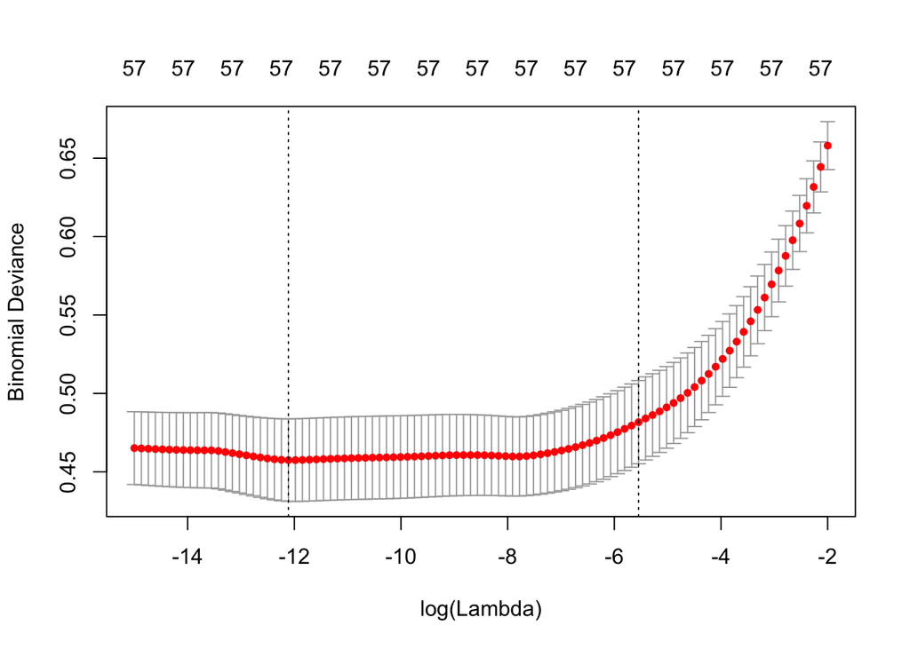

```r
set.seed(1234)
cv.ridge <- cv.glmnet(train.X,train[,58],family="binomial",alpha=0,lambda=exp(seq(-15,-2,length=100)))
plot(cv.ridge)
```

5. Fit a nearest neighbor rule on the training data (use caret to select the number of nearest neigbor by 10 folds cross validation).

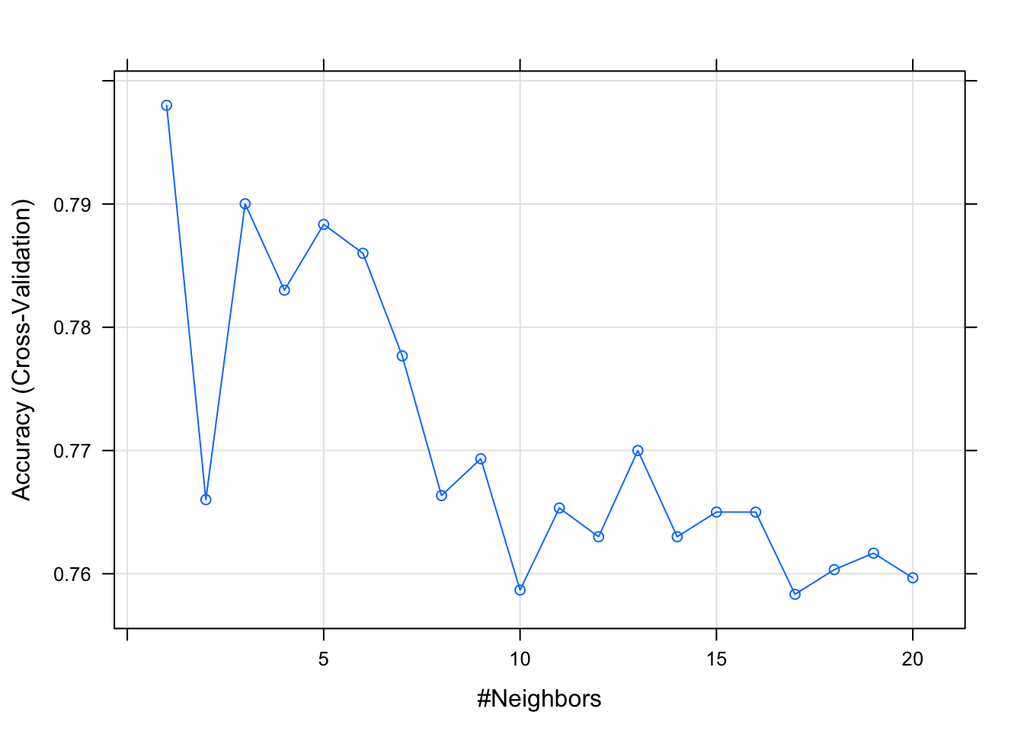

```r
set.seed(1234)
ctrl1 <- trainControl(method="cv",number=10)
grid.k <- data.frame(k=seq(1,20,by=1))
registerDoMC(cores = 5)
sel.k <- train(type~.,data=train,method="knn",trControl=ctrl1,tuneGrid=grid.k)
plot(sel.k)
```

We choose the 1-NN rule.

6. Make a comparison of the 5 methods with the error probability (estimated on the test dataset).

```r
prev.full <- predict(full.logit,newdata=test,type="response") %>% round() %>% as.factor()
prev.full <- fct_recode(prev.full,nonspam="0",spam="1")
prev.back <- predict(mod.back,newdata=test,type="response") %>% round() %>% as.factor()
prev.back <- fct_recode(prev.back,nonspam="0",spam="1")

prev.lasso <- predict(cv.lasso,newx=test.X,type="class",s="lambda.min")
prev.ridge <- predict(cv.ridge,newx=test.X,type="class",s="lambda.min")
prev.knn <- knn(train.X,test.X,train$type,k=1)
prev <- data.frame(full=prev.full,back=prev.back,lasso=as.vector(prev.lasso),ridge=as.vector(prev.ridge),knn=prev.knn,Y=test$type)
prev %>% summarise_at(vars(1:5),~(mean((.!=Y)^2)))
```

| full | back | lasso | ridge | knn |
| --- | --- | --- | --- | --- |
| 0.1274204 | 0.08682074 | 0.08119925 | 0.08057464 | 0.1817614 |

7. Make a comparison of the 5 methods with ROC curve and AUC (estimated on the test dataset).

```r
prev.full <- predict(full.logit,newdata=test,type="response")
prev.back <- predict(mod.back,newdata=test,type="response")
prev.lasso <- predict(cv.lasso,newx=test.X,type="response") %>% as.vector()
prev.ridge <- predict(cv.ridge,newx=test.X,type="response") %>% as.vector()
prev.knn <- knn(train.X,test.X,train$type,k=1,prob=TRUE)
score.knn <- attributes(prev.knn)$prob
score <- data.frame(full=prev.full,back=prev.back,lasso=prev.lasso,ridge=prev.ridge,knn=score.knn,Y=test$type)
score1 <- score %>% gather(key="Method",value="score",-Y)
score1 %>% group_by(Method) %>% summarize(AUC=pROC::auc(Y,score)) %>% arrange(desc(AUC))
```

| Method | AUC |
| --- | --- |
| lasso | 0.9686816 |
| back | 0.9675176 |
| ridge | 0.9663716 |
| full | 0.8604147 |
| knn | 0.4997302 |

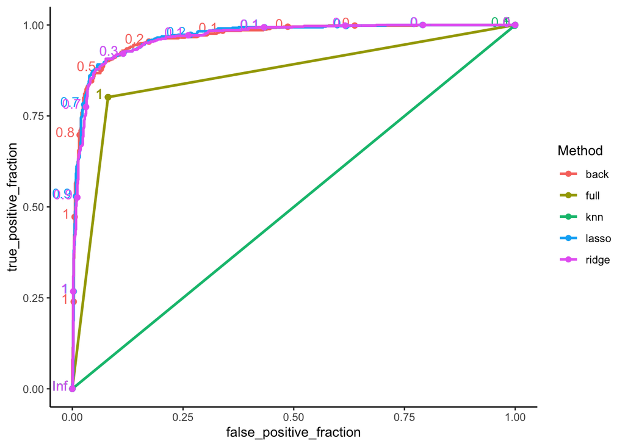

```r
ggplot(score1)+aes(d=Y,m=score,color=Method)+geom_roc()+theme_classic()
```